# Risk Factor Analysis

## Outcome Variable

**Outcome Variable:** ever_co

## Predictor Variables

**Intervention Variable:** perdiar6

**Adjustment Set:**

- arm
- sex
- W_mage
- meducyrs
- W_mhtcm
- W_mwtkg
- W_mbmi
- W_birthwt
- W_birthlen
- W_nrooms
- month
- brthmon
- impfloor
- impsan
- safeh20
- delta_W_mage
- delta_meducyrs
- delta_W_mhtcm
- delta_W_mwtkg
- delta_W_mbmi
- delta_W_birthwt
- delta_W_birthlen
- delta_W_nrooms
- delta_month
- delta_brthmon
- delta_impfloor
- delta_impsan
- delta_safeh20

## Stratifying Variables

The analysis was stratified on these variable(s):

- agecat
- studyid
- country

## Data Summary

| agecat | studyid | country | perdiar6 | ever_co | n_cell | n |
| --- | --- | --- | --- | --- | --- | --- |
| 0-24 months | ki0047075b-MAL-ED | BANGLADESH | 0% | 0 | 70 | 263 |
| 0-24 months | ki0047075b-MAL-ED | BANGLADESH | 0% | 1 | 15 | 263 |
| 0-24 months | ki0047075b-MAL-ED | BANGLADESH | (0%, 5%] | 0 | 83 | 263 |
| 0-24 months | ki0047075b-MAL-ED | BANGLADESH | (0%, 5%] | 1 | 15 | 263 |
| 0-24 months | ki0047075b-MAL-ED | BANGLADESH | >5% | 0 | 71 | 263 |
| 0-24 months | ki0047075b-MAL-ED | BANGLADESH | >5% | 1 | 9 | 263 |
| 0-24 months | ki0047075b-MAL-ED | BRAZIL | 0% | 0 | 214 | 233 |
| 0-24 months | ki0047075b-MAL-ED | BRAZIL | 0% | 1 | 2 | 233 |
| 0-24 months | ki0047075b-MAL-ED | BRAZIL | (0%, 5%] | 0 | 15 | 233 |
| 0-24 months | ki0047075b-MAL-ED | BRAZIL | (0%, 5%] | 1 | 0 | 233 |
| 0-24 months | ki0047075b-MAL-ED | BRAZIL | >5% | 0 | 2 | 233 |
| 0-24 months | ki0047075b-MAL-ED | BRAZIL | >5% | 1 | 0 | 233 |
| 0-24 months | ki0047075b-MAL-ED | INDIA | 0% | 0 | 46 | 251 |
| 0-24 months | ki0047075b-MAL-ED | INDIA | 0% | 1 | 15 | 251 |
| 0-24 months | ki0047075b-MAL-ED | INDIA | (0%, 5%] | 0 | 105 | 251 |
| 0-24 months | ki0047075b-MAL-ED | INDIA | (0%, 5%] | 1 | 24 | 251 |
| 0-24 months | ki0047075b-MAL-ED | INDIA | >5% | 0 | 46 | 251 |
| 0-24 months | ki0047075b-MAL-ED | INDIA | >5% | 1 | 15 | 251 |
| 0-24 months | ki0047075b-MAL-ED | NEPAL | 0% | 0 | 73 | 240 |
| 0-24 months | ki0047075b-MAL-ED | NEPAL | 0% | 1 | 10 | 240 |
| 0-24 months | ki0047075b-MAL-ED | NEPAL | (0%, 5%] | 0 | 73 | 240 |
| 0-24 months | ki0047075b-MAL-ED | NEPAL | (0%, 5%] | 1 | 4 | 240 |
| 0-24 months | ki0047075b-MAL-ED | NEPAL | >5% | 0 | 73 | 240 |
| 0-24 months | ki0047075b-MAL-ED | NEPAL | >5% | 1 | 7 | 240 |
| 0-24 months | ki0047075b-MAL-ED | PERU | 0% | 0 | 84 | 302 |
| 0-24 months | ki0047075b-MAL-ED | PERU | 0% | 1 | 5 | 302 |
| 0-24 months | ki0047075b-MAL-ED | PERU | (0%, 5%] | 0 | 89 | 302 |
| 0-24 months | ki0047075b-MAL-ED | PERU | (0%, 5%] | 1 | 4 | 302 |
| 0-24 months | ki0047075b-MAL-ED | PERU | >5% | 0 | 117 | 302 |
| 0-24 months | ki0047075b-MAL-ED | PERU | >5% | 1 | 3 | 302 |

[output cut: 258 more lines]

The following strata were considered:

- agecat: 0-24 months, studyid: ki0047075b-MAL-ED, country: BANGLADESH
- agecat: 0-24 months, studyid: ki0047075b-MAL-ED, country: BRAZIL
- agecat: 0-24 months, studyid: ki0047075b-MAL-ED, country: INDIA
- agecat: 0-24 months, studyid: ki0047075b-MAL-ED, country: NEPAL
- agecat: 0-24 months, studyid: ki0047075b-MAL-ED, country: PERU
- agecat: 0-24 months, studyid: ki0047075b-MAL-ED, country: SOUTH AFRICA
- agecat: 0-24 months, studyid: ki0047075b-MAL-ED, country: TANZANIA, UNITED REPUBLIC OF
- agecat: 0-24 months, studyid: ki1000109-ResPak, country: PAKISTAN
- agecat: 0-24 months, studyid: ki1017093-NIH-Birth, country: BANGLADESH
- agecat: 0-24 months, studyid: ki1017093b-PROVIDE, country: BANGLADESH
- agecat: 0-24 months, studyid: ki1017093c-NIH-Crypto, country: BANGLADESH
- agecat: 0-24 months, studyid: ki1114097-CMIN, country: BANGLADESH
- agecat: 0-24 months, studyid: ki1114097-CMIN, country: BRAZIL
- agecat: 0-24 months, studyid: ki1114097-CMIN, country: GUINEA-BISSAU
- agecat: 0-24 months, studyid: ki1114097-CMIN, country: PERU
- agecat: 0-24 months, studyid: ki1114097-CONTENT, country: PERU
- agecat: 0-6 months, studyid: ki0047075b-MAL-ED, country: BANGLADESH
- agecat: 0-6 months, studyid: ki0047075b-MAL-ED, country: BRAZIL
- agecat: 0-6 months, studyid: ki0047075b-MAL-ED, country: INDIA
- agecat: 0-6 months, studyid: ki0047075b-MAL-ED, country: NEPAL
- agecat: 0-6 months, studyid: ki0047075b-MAL-ED, country: PERU
- agecat: 0-6 months, studyid: ki0047075b-MAL-ED, country: SOUTH AFRICA
- agecat: 0-6 months, studyid: ki0047075b-MAL-ED, country: TANZANIA, UNITED REPUBLIC OF
- agecat: 0-6 months, studyid: ki1000109-ResPak, country: PAKISTAN
- agecat: 0-6 months, studyid: ki1017093-NIH-Birth, country: BANGLADESH
- agecat: 0-6 months, studyid: ki1017093b-PROVIDE, country: BANGLADESH
- agecat: 0-6 months, studyid: ki1017093c-NIH-Crypto, country: BANGLADESH
- agecat: 0-6 months, studyid: ki1114097-CMIN, country: BANGLADESH
- agecat: 0-6 months, studyid: ki1114097-CMIN, country: BRAZIL
- agecat: 0-6 months, studyid: ki1114097-CMIN, country: GUINEA-BISSAU
- agecat: 0-6 months, studyid: ki1114097-CMIN, country: PERU
- agecat: 0-6 months, studyid: ki1114097-CONTENT, country: PERU
- agecat: 6-24 months, studyid: ki0047075b-MAL-ED, country: BANGLADESH
- agecat: 6-24 months, studyid: ki0047075b-MAL-ED, country: BRAZIL
- agecat: 6-24 months, studyid: ki0047075b-MAL-ED, country: INDIA
- agecat: 6-24 months, studyid: ki0047075b-MAL-ED, country: NEPAL
- agecat: 6-24 months, studyid: ki0047075b-MAL-ED, country: PERU
- agecat: 6-24 months, studyid: ki0047075b-MAL-ED, country: SOUTH AFRICA
- agecat: 6-24 months, studyid: ki0047075b-MAL-ED, country: TANZANIA, UNITED REPUBLIC OF
- agecat: 6-24 months, studyid: ki1000109-ResPak, country: PAKISTAN
- agecat: 6-24 months, studyid: ki1017093-NIH-Birth, country: BANGLADESH
- agecat: 6-24 months, studyid: ki1017093b-PROVIDE, country: BANGLADESH
- agecat: 6-24 months, studyid: ki1017093c-NIH-Crypto, country: BANGLADESH
- agecat: 6-24 months, studyid: ki1114097-CMIN, country: BANGLADESH
- agecat: 6-24 months, studyid: ki1114097-CMIN, country: BRAZIL
- agecat: 6-24 months, studyid: ki1114097-CMIN, country: GUINEA-BISSAU
- agecat: 6-24 months, studyid: ki1114097-CMIN, country: PERU
- agecat: 6-24 months, studyid: ki1114097-CONTENT, country: PERU

### Dropped Strata

Some strata were dropped due to rare outcomes:

- agecat: 0-24 months, studyid: ki0047075b-MAL-ED, country: BRAZIL
- agecat: 0-24 months, studyid: ki0047075b-MAL-ED, country: NEPAL
- agecat: 0-24 months, studyid: ki0047075b-MAL-ED, country: PERU
- agecat: 0-24 months, studyid: ki0047075b-MAL-ED, country: SOUTH AFRICA
- agecat: 0-24 months, studyid: ki0047075b-MAL-ED, country: TANZANIA, UNITED REPUBLIC OF
- agecat: 0-24 months, studyid: ki1000109-ResPak, country: PAKISTAN
- agecat: 0-24 months, studyid: ki1114097-CMIN, country: BRAZIL
- agecat: 0-24 months, studyid: ki1114097-CONTENT, country: PERU
- agecat: 0-6 months, studyid: ki0047075b-MAL-ED, country: BANGLADESH
- agecat: 0-6 months, studyid: ki0047075b-MAL-ED, country: BRAZIL
- agecat: 0-6 months, studyid: ki0047075b-MAL-ED, country: NEPAL
- agecat: 0-6 months, studyid: ki0047075b-MAL-ED, country: PERU
- agecat: 0-6 months, studyid: ki0047075b-MAL-ED, country: SOUTH AFRICA
- agecat: 0-6 months, studyid: ki0047075b-MAL-ED, country: TANZANIA, UNITED REPUBLIC OF
- agecat: 0-6 months, studyid: ki1000109-ResPak, country: PAKISTAN
- agecat: 0-6 months, studyid: ki1017093c-NIH-Crypto, country: BANGLADESH
- agecat: 0-6 months, studyid: ki1114097-CMIN, country: BANGLADESH
- agecat: 0-6 months, studyid: ki1114097-CMIN, country: BRAZIL
- agecat: 0-6 months, studyid: ki1114097-CMIN, country: GUINEA-BISSAU
- agecat: 0-6 months, studyid: ki1114097-CMIN, country: PERU
- agecat: 0-6 months, studyid: ki1114097-CONTENT, country: PERU
- agecat: 6-24 months, studyid: ki0047075b-MAL-ED, country: BRAZIL
- agecat: 6-24 months, studyid: ki0047075b-MAL-ED, country: NEPAL
- agecat: 6-24 months, studyid: ki0047075b-MAL-ED, country: PERU
- agecat: 6-24 months, studyid: ki0047075b-MAL-ED, country: SOUTH AFRICA
- agecat: 6-24 months, studyid: ki0047075b-MAL-ED, country: TANZANIA, UNITED REPUBLIC OF
- agecat: 6-24 months, studyid: ki1000109-ResPak, country: PAKISTAN
- agecat: 6-24 months, studyid: ki1114097-CMIN, country: BRAZIL
- agecat: 6-24 months, studyid: ki1114097-CMIN, country: PERU
- agecat: 6-24 months, studyid: ki1114097-CONTENT, country: PERU

## Methods Detail

We’re interested in the causal parameters $E[Y_a]$ for all values of $a \in \mathcal{A}$. These parameters represent the mean outcome if, possibly contrary to fact, we intervened to set all units to have $A=a$. Under the randomization and positivity assumptions, these are identified by the statistical parameters $\psi_a=E_W[E_{Y|A,W}(Y|A=a,W)]$. In addition, we’re interested in the mean of $Y$, $E[Y]$ under no intervention (the observed mean). We will estimate these parameters by using SuperLearner to fit the relevant likelihood factors – $E_{Y|A,W}(Y|A=a,W)$ and $p(A=a|W)$, and then updating our likelihood fit using a joint TMLE.

For unadjusted analyses ($W=\{\}$), initial likelihoods were estimated using Lrnr_glm to estimate the simple $E(Y|A)$ and Lrnr_mean to estimate $p(A)$. For adjusted analyses, a small library containing Lrnr_glmnet, Lrnr_xgboost, and Lrnr_mean was used.

Having estimated these parameters, we will then use the delta method to estimate relative risks and attributable risks relative to a prespecified baseline level of $A$.

# Results Detail

## Results Plots

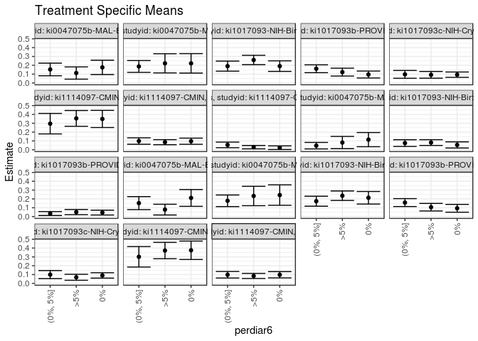

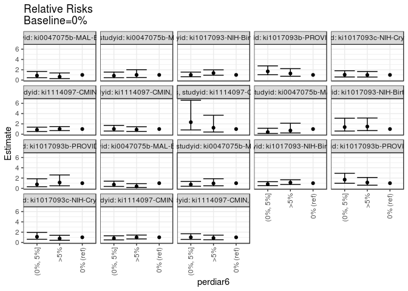

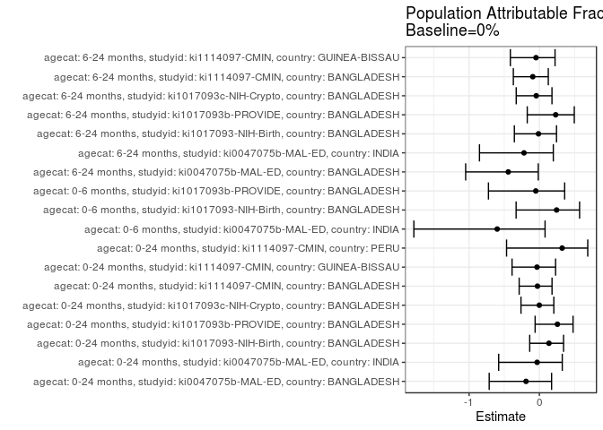

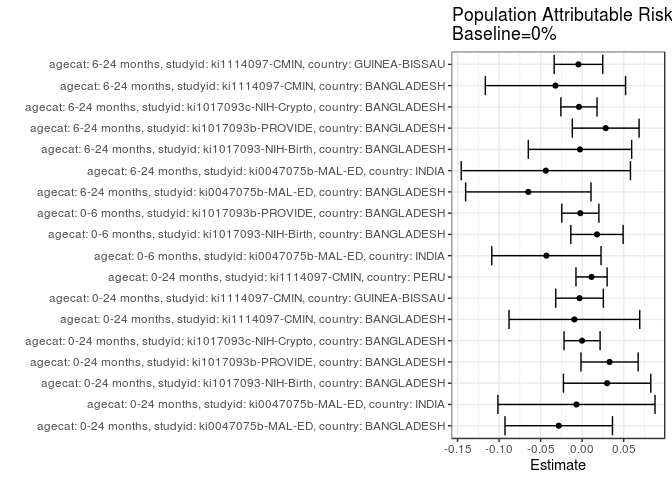

## Results Table

### Parameter: TSM

| agecat | studyid | country | intervention_level | baseline_level | estimate | ci_lower | ci_upper |
| --- | --- | --- | --- | --- | --- | --- | --- |
| 0-24 months | ki0047075b-MAL-ED | BANGLADESH | 0% | NA | 0.1764706 | 0.0952733 | 0.2576679 |
| 0-24 months | ki0047075b-MAL-ED | BANGLADESH | (0%, 5%] | NA | 0.1530612 | 0.0816411 | 0.2244814 |
| 0-24 months | ki0047075b-MAL-ED | BANGLADESH | >5% | NA | 0.1125000 | 0.0431270 | 0.1818730 |
| 0-24 months | ki0047075b-MAL-ED | INDIA | 0% | NA | 0.2220007 | 0.1118905 | 0.3321109 |
| 0-24 months | ki0047075b-MAL-ED | INDIA | (0%, 5%] | NA | 0.1870963 | 0.1203289 | 0.2538636 |
| 0-24 months | ki0047075b-MAL-ED | INDIA | >5% | NA | 0.2222959 | 0.1137629 | 0.3308290 |
| 0-24 months | ki1017093-NIH-Birth | BANGLADESH | 0% | NA | 0.1905782 | 0.1306169 | 0.2505395 |
| 0-24 months | ki1017093-NIH-Birth | BANGLADESH | (0%, 5%] | NA | 0.1906408 | 0.1336888 | 0.2475929 |
| 0-24 months | ki1017093-NIH-Birth | BANGLADESH | >5% | NA | 0.2601734 | 0.2072757 | 0.3130711 |
| 0-24 months | ki1017093b-PROVIDE | BANGLADESH | 0% | NA | 0.0955841 | 0.0565879 | 0.1345802 |
| 0-24 months | ki1017093b-PROVIDE | BANGLADESH | (0%, 5%] | NA | 0.1611011 | 0.1166146 | 0.2055875 |
| 0-24 months | ki1017093b-PROVIDE | BANGLADESH | >5% | NA | 0.1228721 | 0.0783226 | 0.1674216 |
| 0-24 months | ki1017093c-NIH-Crypto | BANGLADESH | 0% | NA | 0.0937707 | 0.0637496 | 0.1237919 |
| 0-24 months | ki1017093c-NIH-Crypto | BANGLADESH | (0%, 5%] | NA | 0.0974208 | 0.0531957 | 0.1416459 |
| 0-24 months | ki1017093c-NIH-Crypto | BANGLADESH | >5% | NA | 0.0921150 | 0.0540246 | 0.1302054 |
| 0-24 months | ki1114097-CMIN | BANGLADESH | 0% | NA | 0.3488520 | 0.2517775 | 0.4459265 |
| 0-24 months | ki1114097-CMIN | BANGLADESH | (0%, 5%] | NA | 0.2955494 | 0.1795349 | 0.4115640 |
| 0-24 months | ki1114097-CMIN | BANGLADESH | >5% | NA | 0.3553073 | 0.2659773 | 0.4446374 |
| 0-24 months | ki1114097-CMIN | GUINEA-BISSAU | 0% | NA | 0.0970378 | 0.0622124 | 0.1318632 |
| 0-24 months | ki1114097-CMIN | GUINEA-BISSAU | (0%, 5%] | NA | 0.0988676 | 0.0622847 | 0.1354504 |
| 0-24 months | ki1114097-CMIN | GUINEA-BISSAU | >5% | NA | 0.0859974 | 0.0572323 | 0.1147625 |
| 0-24 months | ki1114097-CMIN | PERU | 0% | NA | 0.0235849 | 0.0031432 | 0.0440266 |
| 0-24 months | ki1114097-CMIN | PERU | (0%, 5%] | NA | 0.0550000 | 0.0233821 | 0.0866179 |
| 0-24 months | ki1114097-CMIN | PERU | >5% | NA | 0.0295082 | 0.0105032 | 0.0485132 |
| 0-6 months | ki0047075b-MAL-ED | INDIA | 0% | NA | 0.1147541 | 0.0346110 | 0.1948972 |
| 0-6 months | ki0047075b-MAL-ED | INDIA | (0%, 5%] | NA | 0.0465116 | 0.0100985 | 0.0829248 |
| 0-6 months | ki0047075b-MAL-ED | INDIA | >5% | NA | 0.0819672 | 0.0129910 | 0.1509434 |
| 0-6 months | ki1017093-NIH-Birth | BANGLADESH | 0% | NA | 0.0548780 | 0.0199945 | 0.0897616 |
| 0-6 months | ki1017093-NIH-Birth | BANGLADESH | (0%, 5%] | NA | 0.0756757 | 0.0375337 | 0.1138177 |
| 0-6 months | ki1017093-NIH-Birth | BANGLADESH | >5% | NA | 0.0814815 | 0.0488234 | 0.1141396 |
| 0-6 months | ki1017093b-PROVIDE | BANGLADESH | 0% | NA | 0.0450450 | 0.0177429 | 0.0723472 |
| 0-6 months | ki1017093b-PROVIDE | BANGLADESH | (0%, 5%] | NA | 0.0344828 | 0.0123304 | 0.0566351 |
| 0-6 months | ki1017093b-PROVIDE | BANGLADESH | >5% | NA | 0.0506912 | 0.0214834 | 0.0798990 |
| 6-24 months | ki0047075b-MAL-ED | BANGLADESH | 0% | NA | 0.2112676 | 0.1161172 | 0.3064180 |
| 6-24 months | ki0047075b-MAL-ED | BANGLADESH | (0%, 5%] | NA | 0.1521739 | 0.0786230 | 0.2257248 |
| 6-24 months | ki0047075b-MAL-ED | BANGLADESH | >5% | NA | 0.0789474 | 0.0181951 | 0.1396997 |
| 6-24 months | ki0047075b-MAL-ED | INDIA | 0% | NA | 0.2437206 | 0.1279929 | 0.3594483 |
| 6-24 months | ki0047075b-MAL-ED | INDIA | (0%, 5%] | NA | 0.1787914 | 0.1131592 | 0.2444236 |
| 6-24 months | ki0047075b-MAL-ED | INDIA | >5% | NA | 0.2331955 | 0.1235268 | 0.3428641 |
| 6-24 months | ki1017093-NIH-Birth | BANGLADESH | 0% | NA | 0.2129554 | 0.1418798 | 0.2840311 |
| 6-24 months | ki1017093-NIH-Birth | BANGLADESH | (0%, 5%] | NA | 0.1738663 | 0.1172927 | 0.2304398 |
| 6-24 months | ki1017093-NIH-Birth | BANGLADESH | >5% | NA | 0.2361683 | 0.1823835 | 0.2899530 |
| 6-24 months | ki1017093b-PROVIDE | BANGLADESH | 0% | NA | 0.0938364 | 0.0495972 | 0.1380757 |
| 6-24 months | ki1017093b-PROVIDE | BANGLADESH | (0%, 5%] | NA | 0.1587255 | 0.1140312 | 0.2034197 |
| 6-24 months | ki1017093b-PROVIDE | BANGLADESH | >5% | NA | 0.1062121 | 0.0634116 | 0.1490126 |
| 6-24 months | ki1017093c-NIH-Crypto | BANGLADESH | 0% | NA | 0.0901677 | 0.0597331 | 0.1206024 |
| 6-24 months | ki1017093c-NIH-Crypto | BANGLADESH | (0%, 5%] | NA | 0.0994364 | 0.0538718 | 0.1450009 |
| 6-24 months | ki1017093c-NIH-Crypto | BANGLADESH | >5% | NA | 0.0692288 | 0.0354294 | 0.1030282 |
| 6-24 months | ki1114097-CMIN | BANGLADESH | 0% | NA | 0.3747835 | 0.2708418 | 0.4787252 |
| 6-24 months | ki1114097-CMIN | BANGLADESH | (0%, 5%] | NA | 0.3010445 | 0.1850628 | 0.4170262 |
| 6-24 months | ki1114097-CMIN | BANGLADESH | >5% | NA | 0.3718867 | 0.2795281 | 0.4642453 |
| 6-24 months | ki1114097-CMIN | GUINEA-BISSAU | 0% | NA | 0.0977245 | 0.0622378 | 0.1332112 |
| 6-24 months | ki1114097-CMIN | GUINEA-BISSAU | (0%, 5%] | NA | 0.0977117 | 0.0606902 | 0.1347332 |
| 6-24 months | ki1114097-CMIN | GUINEA-BISSAU | >5% | NA | 0.0840976 | 0.0551941 | 0.1130011 |

### Parameter: E(Y)

| agecat | studyid | country | intervention_level | baseline_level | estimate | ci_lower | ci_upper |
| --- | --- | --- | --- | --- | --- | --- | --- |
| 0-24 months | ki0047075b-MAL-ED | BANGLADESH | NA | NA | 0.1482890 | 0.1052563 | 0.1913216 |
| 0-24 months | ki0047075b-MAL-ED | INDIA | NA | NA | 0.2151394 | 0.1642023 | 0.2660766 |
| 0-24 months | ki1017093-NIH-Birth | BANGLADESH | NA | NA | 0.2206119 | 0.1879724 | 0.2532514 |
| 0-24 months | ki1017093b-PROVIDE | BANGLADESH | NA | NA | 0.1285714 | 0.1037574 | 0.1533855 |
| 0-24 months | ki1017093c-NIH-Crypto | BANGLADESH | NA | NA | 0.0936675 | 0.0729118 | 0.1144233 |
| 0-24 months | ki1114097-CMIN | BANGLADESH | NA | NA | 0.3394834 | 0.2830004 | 0.3959663 |
| 0-24 months | ki1114097-CMIN | GUINEA-BISSAU | NA | NA | 0.0938865 | 0.0749878 | 0.1127851 |
| 0-24 months | ki1114097-CMIN | PERU | NA | NA | 0.0348675 | 0.0214307 | 0.0483043 |
| 0-6 months | ki0047075b-MAL-ED | INDIA | NA | NA | 0.0717131 | 0.0397302 | 0.1036961 |
| 0-6 months | ki1017093-NIH-Birth | BANGLADESH | NA | NA | 0.0726979 | 0.0522275 | 0.0931683 |
| 0-6 months | ki1017093b-PROVIDE | BANGLADESH | NA | NA | 0.0428571 | 0.0278427 | 0.0578716 |
| 6-24 months | ki0047075b-MAL-ED | BANGLADESH | NA | NA | 0.1464435 | 0.1015265 | 0.1913605 |
| 6-24 months | ki0047075b-MAL-ED | INDIA | NA | NA | 0.2000000 | 0.1487493 | 0.2512507 |
| 6-24 months | ki1017093-NIH-Birth | BANGLADESH | NA | NA | 0.2103321 | 0.1759902 | 0.2446740 |
| 6-24 months | ki1017093b-PROVIDE | BANGLADESH | NA | NA | 0.1221498 | 0.0962275 | 0.1480722 |
| 6-24 months | ki1017093c-NIH-Crypto | BANGLADESH | NA | NA | 0.0863014 | 0.0659171 | 0.1066856 |
| 6-24 months | ki1114097-CMIN | BANGLADESH | NA | NA | 0.3426295 | 0.2837999 | 0.4014590 |
| 6-24 months | ki1114097-CMIN | GUINEA-BISSAU | NA | NA | 0.0932584 | 0.0741430 | 0.1123738 |

### Parameter: RR

| agecat | studyid | country | intervention_level | baseline_level | estimate | ci_lower | ci_upper |
| --- | --- | --- | --- | --- | --- | --- | --- |
| 0-24 months | ki0047075b-MAL-ED | BANGLADESH | 0% | 0% | 1.0000000 | 1.0000000 | 1.0000000 |
| 0-24 months | ki0047075b-MAL-ED | BANGLADESH | (0%, 5%] | 0% | 0.8673469 | 0.4503955 | 1.6702892 |
| 0-24 months | ki0047075b-MAL-ED | BANGLADESH | >5% | 0% | 0.6375000 | 0.2953502 | 1.3760149 |
| 0-24 months | ki0047075b-MAL-ED | INDIA | 0% | 0% | 1.0000000 | 1.0000000 | 1.0000000 |
| 0-24 months | ki0047075b-MAL-ED | INDIA | (0%, 5%] | 0% | 0.8427733 | 0.4591447 | 1.5469346 |
| 0-24 months | ki0047075b-MAL-ED | INDIA | >5% | 0% | 1.0013300 | 0.4988070 | 2.0101195 |
| 0-24 months | ki1017093-NIH-Birth | BANGLADESH | 0% | 0% | 1.0000000 | 1.0000000 | 1.0000000 |
| 0-24 months | ki1017093-NIH-Birth | BANGLADESH | (0%, 5%] | 0% | 1.0003286 | 0.6490058 | 1.5418310 |
| 0-24 months | ki1017093-NIH-Birth | BANGLADESH | >5% | 0% | 1.3651792 | 0.9398355 | 1.9830216 |
| 0-24 months | ki1017093b-PROVIDE | BANGLADESH | 0% | 0% | 1.0000000 | 1.0000000 | 1.0000000 |
| 0-24 months | ki1017093b-PROVIDE | BANGLADESH | (0%, 5%] | 0% | 1.6854382 | 1.0306837 | 2.7561335 |
| 0-24 months | ki1017093b-PROVIDE | BANGLADESH | >5% | 0% | 1.2854865 | 0.7450329 | 2.2179901 |
| 0-24 months | ki1017093c-NIH-Crypto | BANGLADESH | 0% | 0% | 1.0000000 | 1.0000000 | 1.0000000 |
| 0-24 months | ki1017093c-NIH-Crypto | BANGLADESH | (0%, 5%] | 0% | 1.0389255 | 0.5959825 | 1.8110702 |
| 0-24 months | ki1017093c-NIH-Crypto | BANGLADESH | >5% | 0% | 0.9823429 | 0.5823392 | 1.6571058 |
| 0-24 months | ki1114097-CMIN | BANGLADESH | 0% | 0% | 1.0000000 | 1.0000000 | 1.0000000 |
| 0-24 months | ki1114097-CMIN | BANGLADESH | (0%, 5%] | 0% | 0.8472057 | 0.5235267 | 1.3710046 |
| 0-24 months | ki1114097-CMIN | BANGLADESH | >5% | 0% | 1.0185044 | 0.6998640 | 1.4822183 |
| 0-24 months | ki1114097-CMIN | GUINEA-BISSAU | 0% | 0% | 1.0000000 | 1.0000000 | 1.0000000 |
| 0-24 months | ki1114097-CMIN | GUINEA-BISSAU | (0%, 5%] | 0% | 1.0188563 | 0.6086460 | 1.7055369 |
| 0-24 months | ki1114097-CMIN | GUINEA-BISSAU | >5% | 0% | 0.8862260 | 0.5422924 | 1.4482898 |
| 0-24 months | ki1114097-CMIN | PERU | 0% | 0% | 1.0000000 | 1.0000000 | 1.0000000 |
| 0-24 months | ki1114097-CMIN | PERU | (0%, 5%] | 0% | 2.3320000 | 0.8242181 | 6.5980403 |
| 0-24 months | ki1114097-CMIN | PERU | >5% | 0% | 1.2511475 | 0.4249566 | 3.6836005 |
| 0-6 months | ki0047075b-MAL-ED | INDIA | 0% | 0% | 1.0000000 | 1.0000000 | 1.0000000 |
| 0-6 months | ki0047075b-MAL-ED | INDIA | (0%, 5%] | 0% | 0.4053156 | 0.1419600 | 1.1572328 |
| 0-6 months | ki0047075b-MAL-ED | INDIA | >5% | 0% | 0.7142857 | 0.2392998 | 2.1320709 |
| 0-6 months | ki1017093-NIH-Birth | BANGLADESH | 0% | 0% | 1.0000000 | 1.0000000 | 1.0000000 |
| 0-6 months | ki1017093-NIH-Birth | BANGLADESH | (0%, 5%] | 0% | 1.3789790 | 0.6126960 | 3.1036321 |
| 0-6 months | ki1017093-NIH-Birth | BANGLADESH | >5% | 0% | 1.4847737 | 0.7003297 | 3.1478783 |
| 0-6 months | ki1017093b-PROVIDE | BANGLADESH | 0% | 0% | 1.0000000 | 1.0000000 | 1.0000000 |
| 0-6 months | ki1017093b-PROVIDE | BANGLADESH | (0%, 5%] | 0% | 0.7655172 | 0.3165046 | 1.8515265 |
| 0-6 months | ki1017093b-PROVIDE | BANGLADESH | >5% | 0% | 1.1253456 | 0.4876348 | 2.5970311 |
| 6-24 months | ki0047075b-MAL-ED | BANGLADESH | 0% | 0% | 1.0000000 | 1.0000000 | 1.0000000 |
| 6-24 months | ki0047075b-MAL-ED | BANGLADESH | (0%, 5%] | 0% | 0.7202899 | 0.3720423 | 1.3945120 |
| 6-24 months | ki0047075b-MAL-ED | BANGLADESH | >5% | 0% | 0.3736842 | 0.1532046 | 0.9114602 |
| 6-24 months | ki0047075b-MAL-ED | INDIA | 0% | 0% | 1.0000000 | 1.0000000 | 1.0000000 |
| 6-24 months | ki0047075b-MAL-ED | INDIA | (0%, 5%] | 0% | 0.7335914 | 0.4040480 | 1.3319120 |
| 6-24 months | ki0047075b-MAL-ED | INDIA | >5% | 0% | 0.9568146 | 0.4918884 | 1.8611828 |
| 6-24 months | ki1017093-NIH-Birth | BANGLADESH | 0% | 0% | 1.0000000 | 1.0000000 | 1.0000000 |
| 6-24 months | ki1017093-NIH-Birth | BANGLADESH | (0%, 5%] | 0% | 0.8164444 | 0.5123112 | 1.3011262 |
| 6-24 months | ki1017093-NIH-Birth | BANGLADESH | >5% | 0% | 1.1090033 | 0.7404736 | 1.6609481 |
| 6-24 months | ki1017093b-PROVIDE | BANGLADESH | 0% | 0% | 1.0000000 | 1.0000000 | 1.0000000 |
| 6-24 months | ki1017093b-PROVIDE | BANGLADESH | (0%, 5%] | 0% | 1.6915123 | 0.9789983 | 2.9225933 |
| 6-24 months | ki1017093b-PROVIDE | BANGLADESH | >5% | 0% | 1.1318856 | 0.6094100 | 2.1023040 |
| 6-24 months | ki1017093c-NIH-Crypto | BANGLADESH | 0% | 0% | 1.0000000 | 1.0000000 | 1.0000000 |
| 6-24 months | ki1017093c-NIH-Crypto | BANGLADESH | (0%, 5%] | 0% | 1.1027929 | 0.6241910 | 1.9483655 |
| 6-24 months | ki1017093c-NIH-Crypto | BANGLADESH | >5% | 0% | 0.7677779 | 0.4241781 | 1.3897062 |
| 6-24 months | ki1114097-CMIN | BANGLADESH | 0% | 0% | 1.0000000 | 1.0000000 | 1.0000000 |
| 6-24 months | ki1114097-CMIN | BANGLADESH | (0%, 5%] | 0% | 0.8032490 | 0.4980406 | 1.2954948 |
| 6-24 months | ki1114097-CMIN | BANGLADESH | >5% | 0% | 0.9922706 | 0.6839290 | 1.4396246 |
| 6-24 months | ki1114097-CMIN | GUINEA-BISSAU | 0% | 0% | 1.0000000 | 1.0000000 | 1.0000000 |
| 6-24 months | ki1114097-CMIN | GUINEA-BISSAU | (0%, 5%] | 0% | 0.9998693 | 0.5913784 | 1.6905229 |
| 6-24 months | ki1114097-CMIN | GUINEA-BISSAU | >5% | 0% | 0.8605584 | 0.5217391 | 1.4194083 |

### Parameter: PAR

| agecat | studyid | country | intervention_level | baseline_level | estimate | ci_lower | ci_upper |
| --- | --- | --- | --- | --- | --- | --- | --- |
| 0-24 months | ki0047075b-MAL-ED | BANGLADESH | 0% | NA | -0.0281816 | -0.0928591 | 0.0364958 |
| 0-24 months | ki0047075b-MAL-ED | INDIA | 0% | NA | -0.0068612 | -0.1014000 | 0.0876775 |
| 0-24 months | ki1017093-NIH-Birth | BANGLADESH | 0% | NA | 0.0300337 | -0.0225249 | 0.0825923 |
| 0-24 months | ki1017093b-PROVIDE | BANGLADESH | 0% | NA | 0.0329873 | -0.0014337 | 0.0674084 |
| 0-24 months | ki1017093c-NIH-Crypto | BANGLADESH | 0% | NA | -0.0001032 | -0.0217919 | 0.0215856 |
| 0-24 months | ki1114097-CMIN | BANGLADESH | 0% | NA | -0.0093686 | -0.0880318 | 0.0692945 |
| 0-24 months | ki1114097-CMIN | GUINEA-BISSAU | 0% | NA | -0.0031513 | -0.0318223 | 0.0255196 |
| 0-24 months | ki1114097-CMIN | PERU | 0% | NA | 0.0112826 | -0.0074606 | 0.0300258 |
| 0-6 months | ki0047075b-MAL-ED | INDIA | 0% | NA | -0.0430410 | -0.1087975 | 0.0227156 |
| 0-6 months | ki1017093-NIH-Birth | BANGLADESH | 0% | NA | 0.0178199 | -0.0136619 | 0.0493016 |
| 0-6 months | ki1017093b-PROVIDE | BANGLADESH | 0% | NA | -0.0021879 | -0.0245047 | 0.0201289 |
| 6-24 months | ki0047075b-MAL-ED | BANGLADESH | 0% | NA | -0.0648241 | -0.1402695 | 0.0106213 |
| 6-24 months | ki0047075b-MAL-ED | INDIA | 0% | NA | -0.0437206 | -0.1455709 | 0.0581296 |
| 6-24 months | ki1017093-NIH-Birth | BANGLADESH | 0% | NA | -0.0026233 | -0.0648223 | 0.0595756 |
| 6-24 months | ki1017093b-PROVIDE | BANGLADESH | 0% | NA | 0.0283134 | -0.0118720 | 0.0684989 |
| 6-24 months | ki1017093c-NIH-Crypto | BANGLADESH | 0% | NA | -0.0038664 | -0.0256223 | 0.0178895 |
| 6-24 months | ki1114097-CMIN | BANGLADESH | 0% | NA | -0.0321540 | -0.1165555 | 0.0522474 |
| 6-24 months | ki1114097-CMIN | GUINEA-BISSAU | 0% | NA | -0.0044661 | -0.0336899 | 0.0247578 |

### Parameter: PAF

| agecat | studyid | country | intervention_level | baseline_level | estimate | ci_lower | ci_upper |
| --- | --- | --- | --- | --- | --- | --- | --- |
| 0-24 months | ki0047075b-MAL-ED | BANGLADESH | 0% | NA | -0.1900452 | -0.7139097 | 0.1736976 |
| 0-24 months | ki0047075b-MAL-ED | INDIA | 0% | NA | -0.0318921 | -0.5791012 | 0.3256916 |
| 0-24 months | ki1017093-NIH-Birth | BANGLADESH | 0% | NA | 0.1361382 | -0.1375177 | 0.3439598 |
| 0-24 months | ki1017093b-PROVIDE | BANGLADESH | 0% | NA | 0.2565682 | -0.0606171 | 0.4788970 |
| 0-24 months | ki1017093c-NIH-Crypto | BANGLADESH | 0% | NA | -0.0011015 | -0.2616202 | 0.2056213 |
| 0-24 months | ki1114097-CMIN | BANGLADESH | 0% | NA | -0.0275967 | -0.2875429 | 0.1798681 |
| 0-24 months | ki1114097-CMIN | GUINEA-BISSAU | 0% | NA | -0.0335653 | -0.3886686 | 0.2307328 |
| 0-24 months | ki1114097-CMIN | PERU | 0% | NA | 0.3235849 | -0.4669086 | 0.6880942 |
| 0-6 months | ki0047075b-MAL-ED | INDIA | 0% | NA | -0.6001821 | -1.7855784 | 0.0807716 |
| 0-6 months | ki1017093-NIH-Birth | BANGLADESH | 0% | NA | 0.2451220 | -0.3311018 | 0.5719029 |
| 0-6 months | ki1017093b-PROVIDE | BANGLADESH | 0% | NA | -0.0510511 | -0.7245378 | 0.3594178 |
| 6-24 months | ki0047075b-MAL-ED | BANGLADESH | 0% | NA | -0.4426559 | -1.0488447 | -0.0158194 |
| 6-24 months | ki0047075b-MAL-ED | INDIA | 0% | NA | -0.2186032 | -0.8522494 | 0.1982755 |
| 6-24 months | ki1017093-NIH-Birth | BANGLADESH | 0% | NA | -0.0124724 | -0.3559134 | 0.2439780 |
| 6-24 months | ki1017093b-PROVIDE | BANGLADESH | 0% | NA | 0.2317925 | -0.1725419 | 0.4966979 |
| 6-24 months | ki1017093c-NIH-Crypto | BANGLADESH | 0% | NA | -0.0448009 | -0.3296208 | 0.1790074 |
| 6-24 months | ki1114097-CMIN | BANGLADESH | 0% | NA | -0.0938450 | -0.3703358 | 0.1268587 |
| 6-24 months | ki1114097-CMIN | GUINEA-BISSAU | 0% | NA | -0.0478892 | -0.4128847 | 0.2228158 |